# pltr_stock

```python
# import libraries
from data_registry import datasets
import pandas as pd
import numpy as np
from statsmodels.gam.api import GLMGam
from statsmodels.gam.api import BSplines
import statsmodels.api as sm
import matplotlib.pyplot as plt
from statsmodels.graphics.tsaplots import plot_acf, plot_pacf
from statsmodels.tsa.arima.model import ARIMA
from arch import arch_model

# utils functions
from utils.mainutil import to_ts
from utils.m1util import get_spline

# internal plot functions
from plots.ts_plot import ts_plot
from plots.residual_plot import residual_plot

import warnings
warnings.filterwarnings("ignore", category=UserWarning, module='statsmodels')
warnings.filterwarnings("ignore", category=RuntimeWarning, module='statsmodels')
warnings.filterwarnings("ignore", category=FutureWarning, module='statsmodels')

from statsmodels.tsa.stattools import adfuller

from statsmodels.tools.sm_exceptions import ConvergenceWarning, ValueWarning
from arch.univariate.base import DataScaleWarning
from contextlib import contextmanager
from sklearn.metrics import mean_squared_error, mean_absolute_error
```

```python
# filename = datasets.get("stock")
df = pd.read_csv("pltr_stock.csv")

df["Date"] = pd.to_datetime(df["Date"])
df.index = df["Date"]
df = df.drop(columns="Date")
```

```python
ts = to_ts(df["Close"])
```

### Exploratory analysis of PLTR daily data

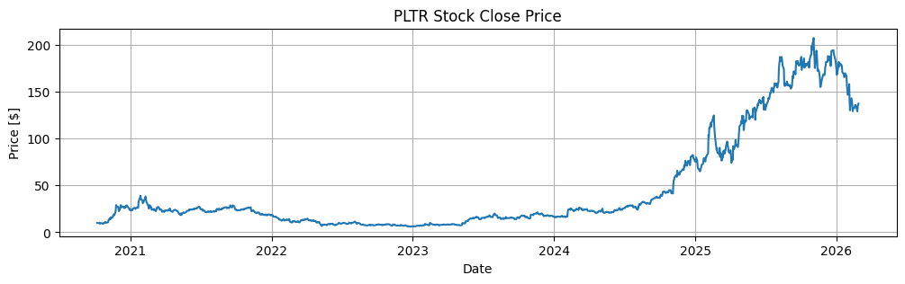

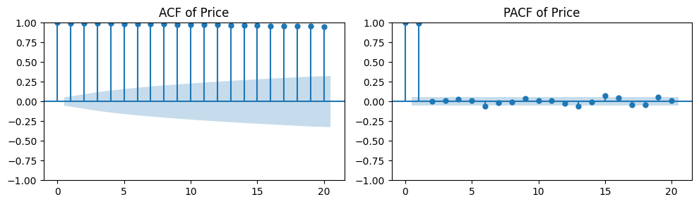

```python
fig = plt.figure(figsize=(12, 3))
plt.plot(ts.index, ts["ts"])
plt.title("PLTR Stock Close Price")
plt.ylabel("Price [$]")
plt.xlabel("Date")
plt.grid(True)
plt.show()

fig, axs = plt.subplots(1, 2, figsize=(10, 3))

plot_acf(ts["ts"] , lags=20, ax=axs[0])
axs[0].set_title("ACF of Price")

plot_pacf(ts["ts"] , lags=20, ax=axs[1], method="ywm")
axs[1].set_title("PACF of Price")

plt.tight_layout()
plt.show()
```

Observations:

PLTR exhibits an overall upward trend and periods of high volatility, especially in more recent years. The ACF of the price shows very strong autocorrelation across many lags, while the PACF has a large spike at lag 1. This suggests that today’s price is highly dependent on yesterday’s price, which is consistent with a random walk behavior. Because of this, modeling the price directly is not very useful for predicting future values, since most of the information is already contained in the last observed price.

### Exploratory analysis of PLTR daily Returns

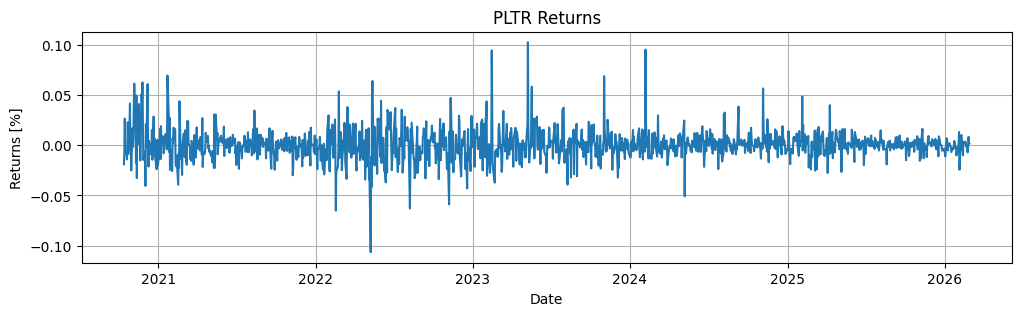

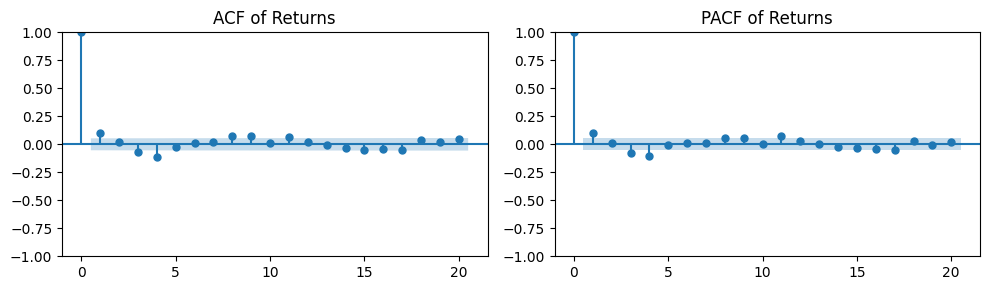

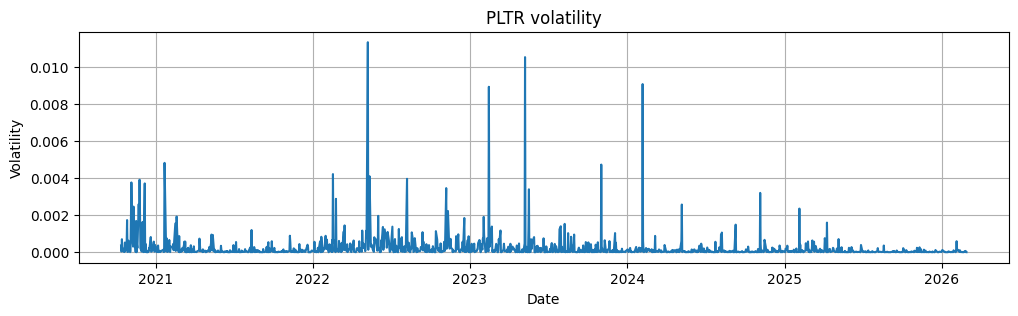

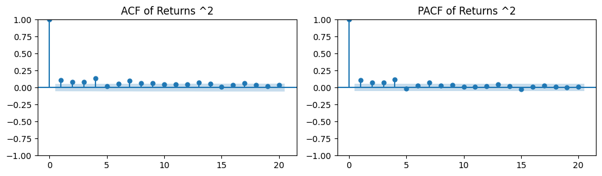

```
Returns ADF Test: p-value: 1.5864911167132463e-16
```

```python
ts["ret"] = np.log(ts["ts"]).pct_change()
ts = ts.dropna()

fig = plt.figure(figsize=(12, 3))
plt.plot(ts.index, ts["ret"])
plt.title("PLTR Returns")
plt.ylabel("Returns [%]")
plt.xlabel("Date")
plt.grid(True)
plt.show()

fig, axs = plt.subplots(1, 2, figsize=(10, 3))

plot_acf(ts["ret"] , lags=20, ax=axs[0])
axs[0].set_title("ACF of Returns")

plot_pacf(ts["ret"] , lags=20, ax=axs[1], method="ywm")
axs[1].set_title("PACF of Returns")

plt.tight_layout()
plt.show()

#--

ts["volatility"] = ts["ret"] ** 2

fig = plt.figure(figsize=(12, 3))
plt.plot(ts.index, ts["volatility"])
plt.title("PLTR volatility")
plt.ylabel("Volatility")
plt.xlabel("Date")
plt.grid(True)
plt.show()

fig, axs = plt.subplots(1, 2, figsize=(10, 3))

plot_acf(ts["volatility"] , lags=20, ax=axs[0])
axs[0].set_title("ACF of Returns ^2")

plot_pacf(ts["volatility"] , lags=20, ax=axs[1], method="ywm")
axs[1].set_title("PACF of Returns ^2")

plt.tight_layout()
plt.show()


result = adfuller(ts["ret"].dropna())
print("Returns ADF Test: p-value:", result[1])
```

Observations:

The squared returns exhibit clear periods of high volatility, indicating the presence of volatility clustering. The ACF and PACF of the squared returns show several significant lags, suggesting short term dependence in the variance. This indicates that, although the mean of the return series behaves approximately like white noise, the volatility is time-dependent. Therefore, a GARCH model is appropriate to capture and model this conditional heteroskedasticity.

### ARIMA model on PLTR Returns

```python
def find_best_arima(series, p_max, d, q_max):

    max_ar=list(range(0,p_max))
    max_ma=list(range(0,q_max))

    aicc_matrix = np.full((len(max_ar), len(max_ma)), np.inf)
    bic_matrix  = np.full((len(max_ar), len(max_ma)), np.inf)

    n = len(series)

    for p in max_ar:
        for q in max_ma:
            try:
                with warnings.catch_warnings():
                    warnings.simplefilter("ignore")
                    fit_result = ARIMA(series, order=(p, d, q)).fit()

                k = len(fit_result.params)
                aicc = fit_result.aic + (2 * k**2 + 2 * k) / (n - k - 1)
                bic = fit_result.bic

                aicc_matrix[p, q] = aicc
                bic_matrix[p, q]  = bic

            except Exception:
                # Skip failed fits silently
                pass

    p_best_aicc, q_best_aicc = np.unravel_index(np.argmin(aicc_matrix), aicc_matrix.shape)
    best_aicc = aicc_matrix[p_best_aicc, q_best_aicc]

    p_best_bic, q_best_bic = np.unravel_index(np.argmin(bic_matrix), bic_matrix.shape)
    best_bic = bic_matrix[p_best_bic, q_best_bic]

    print("Best by AICc:", (p_best_aicc, d, q_best_aicc), "AICc:", best_aicc)
    print("Best by BIC :", (p_best_bic,  d, q_best_bic),  "BIC :", best_bic)
```

```python
p_max = 5
d_max = 0
q_max = 5

find_best_arima(ts["ret"], p_max, d_max, q_max)

arima_model = ARIMA(ts["ret"], order=(4, 0, 0)).fit()

ts["arima_fit"] = arima_model.fittedvalues
ts["arima_res"] = ts["ret"] - ts["arima_fit"]

print(arima_model.summary())
```

```
Best by AICc: (np.int64(4), 0, np.int64(0)) AICc: -7462.242650312749
Best by BIC : (np.int64(4), 0, np.int64(0)) BIC : -7431.058037621757
                               SARIMAX Results
==============================================================================
Dep. Variable:                    ret   No. Observations:                 1350
Model:                 ARIMA(4, 0, 0)   Log Likelihood                3737.153
Date:                Sun, 26 Apr 2026   AIC                          -7462.305
Time:                        15:15:00   BIC                          -7431.058
Sample:                             0   HQIC                         -7450.603
                               - 1350
Covariance Type:                  opg
==============================================================================
                 coef    std err          z      P>|z|      [0.025      0.975]
------------------------------------------------------------------------------
const          0.0007      0.000      1.687      0.092      -0.000       0.001
ar.L1          0.0901      0.021      4.209      0.000       0.048       0.132
ar.L2          0.0221      0.021      1.056      0.291      -0.019       0.063
ar.L3         -0.0650      0.021     -3.050      0.002      -0.107      -0.023
ar.L4         -0.1021      0.021     -4.959      0.000      -0.143      -0.062
sigma2         0.0002   4.55e-06     50.648      0.000       0.000       0.000
===================================================================================
Ljung-Box (L1) (Q):                   0.00   Jarque-Bera (JB):              2592.25
Prob(Q):                              0.96   Prob(JB):                         0.00
Heteroskedasticity (H):               0.27   Skew:                             0.61
Prob(H) (two-sided):                  0.00   Kurtosis:                         9.68
===================================================================================

Warnings:
[1] Covariance matrix calculated using the outer product of gradients (complex-step).
```

Observations:

Using both the AICc and BIC criteria, the ARIMA(4,0,0) model is selected as the best fitting model for the return series. However, inspection of the estimated coefficients shows that not all autoregressive terms are statistically significant, suggesting that some of the included lags may not contribute meaningfully to the model. It is important to note, that the magnitude of the coefficients is relatively small, indicating that the dependence of the return series is weak.

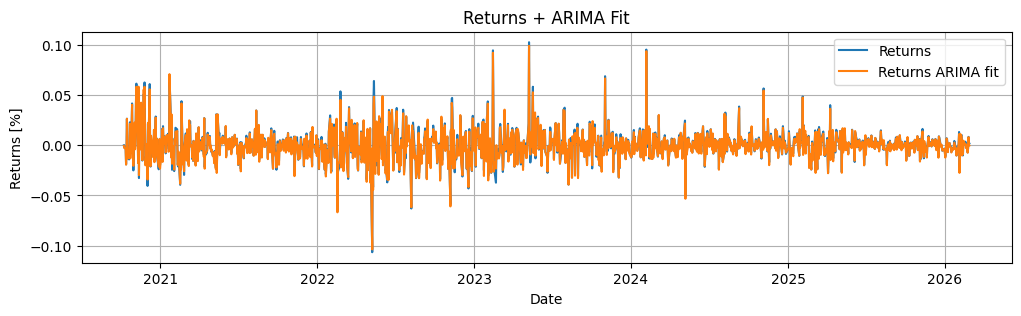

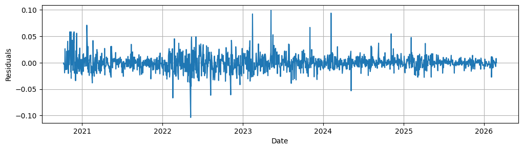

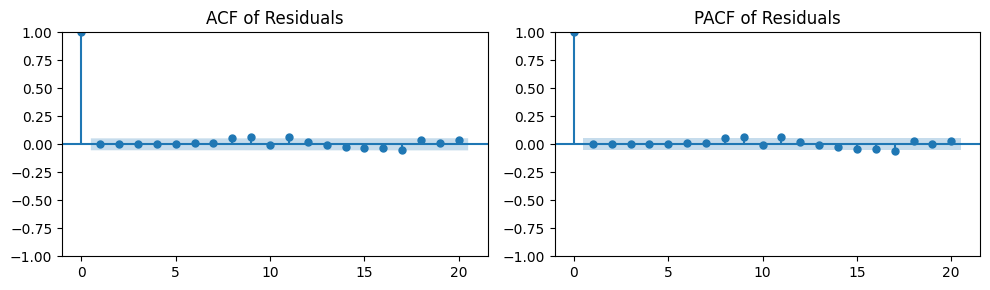

```
ARIMA Residuals: p-value: 0.0
```

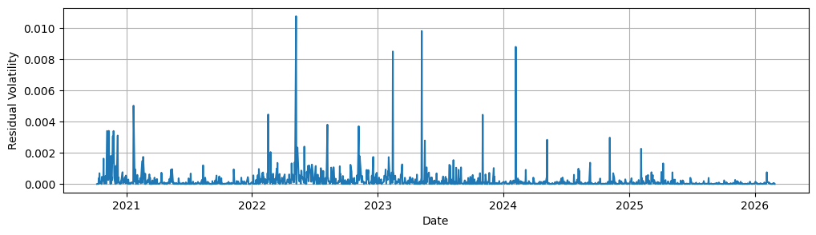

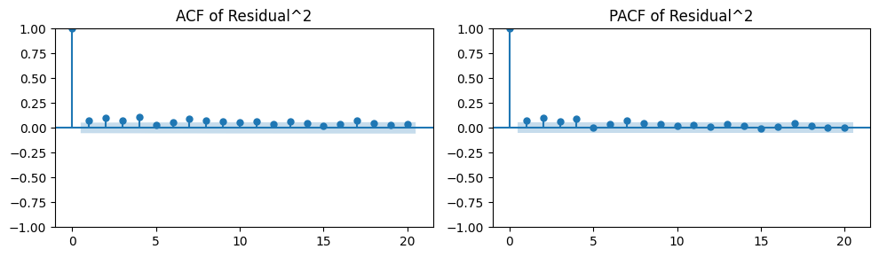

```python
# Data Plots
fig = plt.figure(figsize=(12, 3))
plt.plot(ts.index, ts["ret"], label="Returns")
plt.plot(ts.index, ts["arima_res"], label="Returns ARIMA fit")
plt.title("Returns + ARIMA Fit")
plt.ylabel("Returns [%]")
plt.xlabel("Date")
plt.legend()
plt.grid(True)
plt.show()

# Residual Plots
plt.figure(figsize=(12,3))
plt.plot(ts["arima_res"] )
plt.xlabel("Date")
plt.ylabel("Residuals")
plt.grid(True)
plt.show()

fig, axs = plt.subplots(1, 2, figsize=(10, 3))

plot_acf(ts["arima_res"] , lags=20, ax=axs[0])
axs[0].set_title("ACF of Residuals")

plot_pacf(ts["arima_res"] , lags=20, ax=axs[1], method="ywm")
axs[1].set_title("PACF of Residuals")

plt.tight_layout()
plt.show()


result = adfuller(ts["arima_res"].dropna())
print("ARIMA Residuals: p-value:", result[1])


#---
# Volatility
ts["arima_res_square"] = ts["arima_res"] ** 2

# Residual Plots
plt.figure(figsize=(12,3))
plt.plot(ts["arima_res_square"] )
plt.xlabel("Date")
plt.ylabel("Residual^2")
plt.ylabel("Residual Volatility")
plt.grid(True)
plt.show()

fig, axs = plt.subplots(1, 2, figsize=(10, 3))

plot_acf(ts["arima_res_square"] , lags=20, ax=axs[0])
axs[0].set_title("ACF of Residual^2")

plot_pacf(ts["arima_res_square"] , lags=20, ax=axs[1], method="ywm")
axs[1].set_title("PACF of Residual^2")

plt.tight_layout()
plt.show()
```

Observations:

The ARIMA(4,0,0) model captures the linear dependence in the return series, as evidenced by the lack of significant autocorrelation in the residuals. However, the residual plot reveals periods of varying volatility, and the squared residuals exhibit clear clustering.